# Assignment 3

Nathan Preuss

Saturday, October 17, 2020

# Questions

## I have solved 16/16 Questions.

## Q 1

### A

We are looking for an interarrival time of 2 minutes (120 seconds) or more, or $P(y \ge 120)$. pexp requires that the $rate = \frac{1} {\mu}$, so I passed $\frac{1} {95}$ instead of $95$.

```r
1-pexp(120, 1/95)
```

```
## [1] 0.2827597
```

### B

We are looking to see if the data’s sample mean and variance are close to the mean and standard deviation of an exponential distribution with $\beta = 95$ For reference, the mean of an exponential distribution is $\beta$ and the variance is $\beta^2$. In this case, the exponential distribution would lead us to believe that $\mu = 95$ and $\sigma^2 = 9025$.

```r
phishing <-read.csv("PHISHING.csv")
mean(phishing$INTTIME)
```

```
## [1] 95.52377
```

```r
var(phishing$INTTIME)
```

```
## [1] 8379.411
```

```r
(95.523 - 95) / 95
```

```
## [1] 0.005505263
```

```r
(8379-9025)/9025
```

```
## [1] -0.07157895
```

In reality, the mean is $95.5237$ and the variation is $8379.411$. Because the sample mean is almost exactly equal to the theoretical mean, and because the sample variance is quite close to the theoretical variance, the data appear to follow an exponential distribution with $\beta = 95$.

## Q 2

### A

The textbook for the course defines the mean for a gamma distribution to equal $\mu = \alpha\beta$ and the variance to equal $\sigma^2 = \alpha\beta^2$. Plugging the numbers given $\alpha = 3$ and $\beta = 0.07$ into those two equations, we find that $\mu = 0.21$ and $\sigma^2 = 0.0147$

### B

The maximum flood level was found to be .60 Million Cubic ft/sec. In general, we would expect most maximum flood levels to be within 3 standard deviations of the mean. In this case, $\mu + 3 \sigma = .5737$. Since .60 Million is greater than .5737 Million, this data point is an outlier, and therefore should not be expected. In addition, I reparameterized the function in R to give the probability of finding a maximum flood level greater than .60 Million Cubic ft/sec.

```r
1-pgamma(.60, 3, 1/.07)
```

```
## [1] 0.008772316
```

Indeed, R gives us the probability of a Maximum Flood Level greater than .60 Million cubic feet to be about $0.8772\%$, which is very unlikely and should not be expected. We can infer that the maximum flood level distribution was extremely higher than normal during this four year period.

## Q 3

### A

The textbook for the course defines the mean for a gamma distribution to equal $\mu = \alpha\beta$. For formula A, $\mu_A = \alpha_A\beta_A= 2\times2 = 4$, and for formula B, $\mu_B = \alpha_B\beta_B = 1\times4 = 4$.

### B

The textbook for the course defines the variance for a gamma distribution to equal $\sigma^2 = \alpha\beta^2$. For formula A, $\sigma^2_A = \alpha_A\beta_A^2= 2\times2^2 = 8$, and for formula B, $\sigma^2_B = \alpha_B\beta_B^2 = 1\times4^2 = 16$.

### C

In order to calculate which tear gas is more likely to cause a reaction in less than a minute, we are going to calculate $P(y\le1)$ for formulas A and B using pgamma and compare them.

```r
# formula A
pgamma(1, 2, 1/2)
```

```
## [1] 0.09020401
```

```r
# formula B
pgamma(1, 1, 1/4)
```

```
## [1] 0.2211992
```

For formula A, the probability of causing a reaction in less than 1 minute is 9.0204%, and for formula B the probability is 22.1199%. Therefore, formula B is more likely to cause a reaction in less than 1 minute.

## Q 4

### A

The proportion of washers that need to be repaired can be modeled as a weibull distribution with $P(y\le2)$. After reparameterizing the function for R, we get

```r
pweibull(2, 2, 2)
```

```
## [1] 0.6321206
```

.6321 as the proportion of washer that need repair within the first two years.

### B

Using the definition for mean and variance from the textbook.
$$\mu = \beta^{\frac{1} {\alpha}}\Gamma\left(\frac{\alpha + 1} {\alpha}\right) = 4^{\frac {1} {2}}\Gamma\left(\frac{2+1}{2}\right) = 2\times .88623 = 1.77246$$
$$\sigma^2 = \beta^{\frac{2} {\alpha}}\left[\Gamma(\frac{\alpha + 2} {\alpha}) - \Gamma^2(\frac{\alpha + 1} {\alpha})\right] = 4^{\frac{2}{2}}\left[ \Gamma\left(\frac{4} {2}\right) - \Gamma^2\left(\frac{3}{2}\right)\right] = 4(1-.88623^2) = .8583$$
$$\sigma = \sqrt{\sigma^2} = \sqrt{.8583} = .9265$$

The mean is 1.77246 and the standard deviation is .9265.

### C

$$P(\mu - 2\sigma \le Y \le \mu + 2\sigma) = P(-0.08054 \le Y \le 3.62546)$$

This can be represented by taking the pweibull(3.62546) - pweibull(-0.08054). Using a reparameterized weibull in R, we find that the probability of such an event happening to be .96259.

```r
pweibull(3.62546, 2, 2) - pweibull(-0.08054, 2, 2)
```

```
## [1] 0.9625965
```

### D

To see if it is likely that $P(Y \gt 6)$, we will calculate the odds of such an event happening in R.

```r
1-pweibull(6, 2, 2)
```

```
## [1] 0.0001234098
```

Such an event is extremely unlikely, with a $P(Y \gt 6) = .00012$.

## Q 5

### A

The textbook defines the mean and variance of a beta function such that $\mu = \frac{\alpha}{\alpha + \beta}$ and $\sigma^2 = \frac{\alpha\beta}{(\alpha + \beta)^2(\alpha+\beta+ 1)}$. Plugging in the given valuess for alpha and beta gives us $\mu = \frac {2} {11} = .18182$ and $\sigma^2 = \frac{18} {(11)^2(12)} = .01240$.

### B

We are going to use pbeta to find $P(y\ge.40)$, which represents the probability that in any given year at least 40% of the hardware repair budget will go to the laser printer.

```r
1-pbeta(.4, 2, 9)
```

```
## [1] 0.0463574
```

$P(y\ge.40) = .0464$.

### C

We are going to use pbeta to find $P(y\le .10)$, which reprensts the probability in any given year of at most 10% of the hardware repair budget going to the color printer.

```r
pbeta(.1, 2, 9)
```

```
## [1] 0.2639011
```

$P(y\le .10) = .2639$

## Q 6

### A

I am going to compare the given function with $\frac{\alpha}{\beta}y^{\alpha-1}e^{-y^\alpha\beta}$ $\alpha = 2$ and $\beta = 16$.

### B

Computing the mean and variance.
$$\mu = \beta^{\frac{1} {\alpha}}\Gamma\left(\frac{\alpha + 1} {\alpha}\right) = 16^{\frac {1} {2}}\Gamma\left(\frac{2+1}{2}\right) = 4\times .88623 = 3.54492$$

$$\sigma^2 = \beta^{\frac{2} {\alpha}}\left[\Gamma(\frac{\alpha + 2} {\alpha}) - \Gamma^2(\frac{\alpha + 1} {\alpha})\right] = 16^{\frac{2}{2}}\left[ \Gamma\left(\frac{4} {2}\right) - \Gamma^2\left(\frac{3}{2}\right)\right] = 16(1-.88623^2) = 3.4335$$

### C

The probability that a chip will not fail before 6 years can be represented in R as a pweibull function.

```r
1-pweibull(6, 2, 4)
```

```
## [1] 0.1053992
```

In this case, the probability that a chip will not fail is .1053.

## Q 7

### A

making a table of the joint probability distribution

```r
colNames = c(1,2,3,4,5,6)
row = c(1/36, 1/36, 1/36, 1/36, 1/36, 1/36)
distr <- data.frame(row, row, row, row, row, row)
row.names(distr) <- colNames
names(distr)[1] = "1"
names(distr)[2] = "2"
names(distr)[3] = "3"
names(distr)[4] = "4"
names(distr)[5] = "5"
names(distr)[6] = "6"
distr
```

|  | 1 | 2 | 3 | 4 | 5 | 6 |
| --- | --- | --- | --- | --- | --- | --- |
| 1 | 0.02777778 | 0.02777778 | 0.02777778 | 0.02777778 | 0.02777778 | 0.02777778 |
| 2 | 0.02777778 | 0.02777778 | 0.02777778 | 0.02777778 | 0.02777778 | 0.02777778 |
| 3 | 0.02777778 | 0.02777778 | 0.02777778 | 0.02777778 | 0.02777778 | 0.02777778 |
| 4 | 0.02777778 | 0.02777778 | 0.02777778 | 0.02777778 | 0.02777778 | 0.02777778 |
| 5 | 0.02777778 | 0.02777778 | 0.02777778 | 0.02777778 | 0.02777778 | 0.02777778 |
| 6 | 0.02777778 | 0.02777778 | 0.02777778 | 0.02777778 | 0.02777778 | 0.02777778 |

### B

For X:
$$P(X=1) = p_1(1) = p(1,1) + p(1,2) + p(1,3) + p(1,4) + p(1,5) + p(1,6) = 1/36 + 1/36 + 1/36 + 1/36 + 1/36 + 1/36 = 1/6$$
$$P(X=2) = 1/6$$
$$P(X=3) = 1/6$$
$$P(X=4) = 1/6$$
$$P(X=5) = 1/6$$
$$P(X=6) = 1/6$$

Therefore, $p_1(X) = 1/6$

For Y:
$$P(Y=1) = p_2(1) = p(1,1) + p(2,1) + p(3,1) + p(4,1) + p(5,1) + p(6,1) = 1/36 + 1/36 + 1/36 + 1/36 + 1/36 + 1/36 = 1/6$$
$$P(Y=2) = 1/6$$
$$P(Y=3) = 1/6$$
$$P(Y=4) = 1/6$$
$$P(Y=5) = 1/6$$
$$P(Y=6) = 1/6$$
Therefore, $p_2(Y) = 1/6$

### C

Conditional probability for $p_1(x|y) = \frac{p(x,y)} { p_2(y)}$

Let Y = 1:
$$p_1(1,1) = \frac{p(1, 1)} {p_2(1)} = \frac{1/36} {1/6} = 1/6$$
$$p_1(2,1) = 1/6$$
$$p_1(3,1) = 1/6$$
$$p_1(4,1) = 1/6$$
$$p_1(5,1) = 1/6$$
$$p_1(6,1) = 1/6$$

Conditional probability for $p_2(y|x) = \frac{p(x,y)} { p_1(x)}$

Let X = 1
$$p_2(1,1) = \frac{p(1, 1)} {p_1(1)} = \frac{1/36} {1/6} = 1/6$$
$$p_2(1,2) = 1/6$$
$$p_2(1,3) = 1/6$$
$$p_2(1,4) = 1/6$$
$$p_2(1,5) = 1/6$$
$$p_2(1,6) = 1/6$$

In any case, the conditional probability table looks exactly the joint probability distribution table from part A.

### D

Both the conditional probability and the marginal probability are the same. In this case, the variables are independent, because the occurance of one event does not impact the probability of another event.

## Q 8

### Bivariate Probability Distribution

```r
Energy1<- c(1/7,0/7,0/7)
Energy2<- c(2/7,0/7,0/7)
Energy3<- c(1/7, 2/7, 1/7)
names1 <- c("Time 1", "Time 2", "Time 3")
df <- data.frame(Energy1,Energy2,Energy3)
row.names(df) <- names1
df
```

|  | Energy1 | Energy2 | Energy3 |
| --- | --- | --- | --- |
| Time 1 | 0.1428571 | 0.2857143 | 0.1428571 |
| Time 2 | 0.0000000 | 0.0000000 | 0.2857143 |
| Time 3 | 0.0000000 | 0.0000000 | 0.1428571 |

### $P_1(X)$

Adding P1 as a summary row on to the table

```r
P1 <- c(sum(Energy1), sum(Energy2), sum(Energy3))
df<- rbind(df, P1)
names1 <- c("Time 1", "Time 2", "Time 3", "P1")
row.names(df) <- names1
df
```

|  | Energy1 | Energy2 | Energy3 |
| --- | --- | --- | --- |
| Time 1 | 0.1428571 | 0.2857143 | 0.1428571 |
| Time 2 | 0.0000000 | 0.0000000 | 0.2857143 |
| Time 3 | 0.0000000 | 0.0000000 | 0.1428571 |
| P1 | 0.1428571 | 0.2857143 | 0.5714286 |

### $P_2(Y)$

Doing the same as above, except P2 is being added as a column.

```r
Pa2 <- Energy1 + Energy2 + Energy3
P2<- c(Pa2, 0)
df <- cbind(df, P2)
df
```

|  | Energy1 | Energy2 | Energy3 | P2 |
| --- | --- | --- | --- | --- |
| Time 1 | 0.1428571 | 0.2857143 | 0.1428571 | 0.5714286 |
| Time 2 | 0.0000000 | 0.0000000 | 0.2857143 | 0.2857143 |
| Time 3 | 0.0000000 | 0.0000000 | 0.1428571 | 0.1428571 |
| P1 | 0.1428571 | 0.2857143 | 0.5714286 | 0.0000000 |

### $P_2(y|x)$

Creating a new dataframe to show the conditional distribution

```r
EnergyLvl1<- Energy1/sum(Energy1)
EnergyLvl2<- Energy2/sum(Energy2)
EnergyLvl3<- Energy3/sum(Energy3)
names2 <- c(1:3)
df2 <- data.frame(EnergyLvl1, EnergyLvl2, EnergyLvl3)
row.names(df2) <- names2
names(df2)[1] = "P2(y|1)"
names(df2)[2] = "P2(y|2)"
names(df2)[3] = "P2(y|3)"

df2
```

|  | P2(y\|1) | P2(y\|2) | P2(y\|3) |
| --- | --- | --- | --- |
| 1 | 1 | 1 | 0.25 |
| 2 | 0 | 0 | 0.50 |
| 3 | 0 | 0 | 0.25 |

## Q 9

### A

$$f_2(y)= \int_y^{2y}f(x,y)dx$$
$$= \int_y^{2y}\frac{e^{-y/10}}{10y}dx$$
$$= \frac{e^{-y/10}}{10y}x\Big|_y^{2y}$$
$$= \frac{e^{-y/10}}{10y}2y - \frac{e^{-y/10}}{10y}y$$
$$= \frac{e^{-y/10}}{10}$$
This looks remarkably similar to an exponential continuous random variable.

### B

Because this is similar to a continuous random variable, and because the expected value, or the mean, of a continuous random variable is $\beta$, then the expected value of this function is 10, since in this case, $\beta = 10$.

## Q 10

### A: Solving for C

$$\int_{-\infty}^\infty\int_{-\infty}^\infty f(x,y)dydx = 1$$
$$\int_0^\infty\int_{0}^x ce^{-x^2}dydx = 1$$
$$\int_0^\infty ce^{-x^2}y \Big|^x_0dx = 1$$
$$\int_0^\infty cxe^{-x^2} - 0dx = 1$$
$$\frac{cxe^{-x^2}}{-2x} \Big|^\infty_0 = 1$$
As X approaches infinity, $e^{-x^2}$ approaches 0.
$$0 - \frac{ce^{-0^2}}{-2} = 1$$
$$c/2 = 1$$
$$c = 2$$

### B

We are trying to prove that
$$\int^\infty_{-\infty}f_1(x)dx = 1$$

$$f_1(x) = \int^\infty_{-\infty}f_1(x,y)dy = 1$$
$$2\int^x_{0}e^{-x^2}dy = 1$$
$$2ye^{-x^2}\Big|^x_0 = 1$$
$$2xe^{-x^2} - 0= 1$$
$$f_1(x) = 2xe^{-x^2}$$

Thus

$$\int^\infty_{-\infty}f_1(x)dx = 2\int_0^\infty xe^{-x^2}dx$$
$$\frac{2xe^{-x^2}}{-2x} \Big|^\infty_0$$
As X approaches infinity, $e^{-x^2}$ approaches 0.
$$0 - \frac{2e^{-0^2}}{-2} = 1$$
$$\frac{-2}{-2} = 1$$

Thus it has been proven.

### C

Using $f_1(x) = 1$, we are going to solve the conditional density for Y given X.

First, we are going to derive the conditional density formula.
$$f_2(y|x) = \frac{f(x,y)}{f_1(x)} = \frac{2e^{-x^2}}{1} = 2e^{-x^2}$$
As shown above,
$$2\int_0^\infty xe^{-x^2}dx = 1$$
Thus, the conditional density function is a uniform distribution over $0 \le Y \le X$ with density $1/X$.

## Q 11

$COV(X,Y) = E(XY) - E(X)E(Y)$. With $E(XY) = 0$, $E(X) = 0$, and $E(Y) = 0$, $COV(X,Y) = 0$. However, because the probability of $f(0,0) = 0$, then if $X= 1$, Y can only take on the values of 1 or -1. Therefore, Y is not free to take on any value and is dependent upon X.

## Q 12

### A

Since this takes on a uniform distribution, the expected value of a uniform distribution is $\frac{a+b}2$, so in this case, $\frac{1+3} 2 = 2 = E(\overline Y)$.

### B

The variance of a uniform distribution is $\frac{(b-a)^2}{12n} = 0.0055$

### C

Using CLT for a uniform distribution with a 1000 iterations and a sample size of 60.

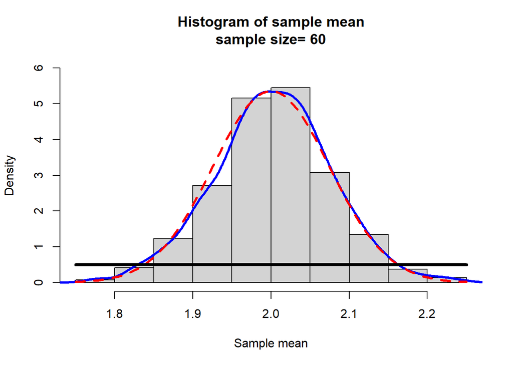

```r
################### uniform ##########################
### CLT uniform
## my Central Limit Function
## Notice that I have assigned default values which can be changed when the function is called
mycltu=function(n,iter,a=0,b=10){
## r-random sample from the uniform
y=runif(n*iter,a,b)
## Place these numbers into a matrix
## The columns will correspond to the iteration and the rows will equal the sample size n
data=matrix(y,nr=n,nc=iter,byrow=TRUE)
## apply the function mean to the columns (2) of the matrix
## these are placed in a vector w
w=apply(data,2,mean)
## We will make a histogram of the values in w
## How high should we make y axis?
## All the values used to make a histogram are placed in param (nothing is plotted yet)
param=hist(w,plot=FALSE)
## Since the histogram will be a density plot we will find the max density

ymax=max(param$density)
## To be on the safe side we will add 10% more to this
ymax=1.1*ymax
## Now we can make the histogram
hist(w,freq=FALSE,  ylim=c(0,ymax), main=paste("Histogram of sample mean",
"\n", "sample size= ",n,sep=""),xlab="Sample mean")
## add a density curve made from the sample distribution
lines(density(w),col="Blue",lwd=3) # add a density plot
## Add a theoretical normal curve
curve(dnorm(x,mean=(a+b)/2,sd=(b-a)/(sqrt(12*n))),add=TRUE,col="Red",lty=2,lwd=3) # add a theoretical curve
## Add the density from which the samples were taken
curve(dunif(x,a,b),add=TRUE,lwd=4)

}
mycltu(n=60,iter=1000, a=1, b=3)
```

It looks like a normal distribution.

### D

Using pnorm with the mean and variance calculated above.

```r
pnorm(2.5, 2, 0.0055) - pnorm(1.5, 2, .0055)
```

```
## [1] 1
```

The probability of $1.5 \le \overline Y \le 2.5 = 1$

### E

Using pnorm to solve $\overline Y \gt 2.2$

```r
1-pnorm(2.2, 2, 0.00556)
```

```
## [1] 0
```

R is giving me 0, but from the looks of the histogram above, there exists a very tiny chance that $\overline Y \gt 2.2$. I believe the .9963 in the answer key comes from the probability of $\overline Y \lt 2.2$.

## Q 13

### A

I will be using continuity correction for the normal approximation to a binomial probability.

$$P(Y \le 1) \approx P(Z < \frac{(1+.5 - 20*.40)}{\sqrt{20*.40*.60}})) = P(Z < -2.9668)$$

Using pnorm to estimate the probability of the normal distribution

```r
pnorm(-2.9668)
```

```
## [1] 0.001504583
```

The probability is .0015.

### B

Using the same theorem as above, but this time calculating the chances that more than 10 swordfish are contaminated. $P(Y\ge 11) \approx P(Z>.1.1410)$

```r
1 - pnorm(1.1410)
```

```
## [1] 0.126935
```

The probability is .1269.

### C

I will use pbinom to compare determine the actual values and compare them to the calculated normal values.

```r
pbinom(1, 20, .4)
```

```
## [1] 0.0005240494
```

```r
1-pbinom(10, 20, .4)
```

```
## [1] 0.1275212
```

The normal approximation values are close to the binomial values. The binomial value for part A was .0005, while the normal value was .0015, and the binomial value for part B was .1275 and the normal value was .1269. As a result, the normal distribution provides a good approximation to the binomial distribution.

## Q 14

### A

I will be constructing a 99% confidence interval for the mean lead level in water using R code provided for this assignment.

```r
# Q 14

library(readxl)
dird = "C:\\Users\\Nathan\\Downloads\\Data-for-the-course\\K25936_Downloads\\Excel\\"

myread = function(xls){
  require(readxl)
read_xls(paste0(dird, xls))
}

leadcop = myread("LEADCOPP.xls")
solrad = myread("SOLARAD.xls")
diazinon = myread("DIAZINON.xls")

t.test(leadcop$LEAD,conf.level = 0.99)
```

```
##
##  One Sample t-test
##
## data:  leadcop$LEAD
## t = 2.325, df = 9, p-value = 0.04512
## alternative hypothesis: true mean is not equal to 0
## 99 percent confidence interval:
##  -1.147845  6.919045
## sample estimates:
## mean of x
##    2.8856
```

The 99% confidence interval is (-1.1478, 6.9190).

### B

The 99% confidence interval, except this time for mean copper level.

```r
t.test(leadcop$COPPER,conf.level = 0.99)
```

```
##
##  One Sample t-test
##
## data:  leadcop$COPPER
## t = 5.1746, df = 9, p-value = 0.0005836
## alternative hypothesis: true mean is not equal to 0
## 99 percent confidence interval:
##  0.1518726 0.6647274
## sample estimates:
## mean of x
##    0.4083
```

The 99% confidence interval is (.1518, .6647).

### C

In the context of the problem, we would expect to see 99% of measured values for the mean lead level to fall between -1.1478 and 6.9190 micrograms per Liter. Similarly, we would expect to see 99% of measured values for the copper mean to fall between .1518 and .6647 micrograms per Liter.

### D

The phrase 99% confidence means that, if we were to employ our interval estimator on multiple occasions, we would expect to see 99% of the intervals constructed contain the true parameter value.

## Q 15

### A

Using provided R code, I will find a 95% confidence interval for the mean difference between the two sites, using the small sample formula for matched pairs because the number of records is small.

```r
with(solrad, t.test(STJOS, IOWA, paired=TRUE, conf.level = 0.95))
```

```
##
##  Paired t-test
##
## data:  STJOS and IOWA
## t = 11.765, df = 6, p-value = 2.277e-05
## alternative hypothesis: true difference in means is not equal to 0
## 95 percent confidence interval:
##  156.8193 239.1807
## sample estimates:
## mean of the differences
##                     198
```

The 95% confidence interval is (156.8193, 239.1807).

## Q 16

### A

Using provided R code, I will construct a 90% confidence interval for the mean difference between the two categories, using the small sample formula for matched pairs because, again, the sample size is small.

```r
with( diazinon, t.test(DAY, NIGHT, paired =TRUE, conf.level = .90))
```

```
##
##  Paired t-test
##
## data:  DAY and NIGHT
## t = -3.5278, df = 10, p-value = 0.005467
## alternative hypothesis: true difference in means is not equal to 0
## 90 percent confidence interval:
##  -58.89917 -18.91901
## sample estimates:
## mean of the differences
##               -38.90909
```

The 90% confidence interval is (-58.8992, -18.9190).

### B

We are assuming that the population of paired differences is normally distributed.

### C

The mean diazinon levels do differ between day and night. The 90% confidence interval tells us that the mean difference between the amount of diazinon between day and night is going to fall between -58.8992 and -18.9190. Thus, the amount of diazinon in the day is, on average, less than the amount of diazinon at night.